# Responsible Use of Agentic AI: Adversarial Review

Bioinformatics Resource Center - Rockefeller University

brc@rockefeller.edu

## Overview

- Why review AI output?
- What is adversarial review?
- Why not ask the same AI?
- What the evidence says
- A worked example
- How to do it
- BRC’s code reviewer

## LLMs are often confident, but wrong

ChatGPT-3.5 was asked to write 30 short medical papers with references.

However, it ‘hallucinated’ up to 93% of the references, often just making up papers with wrong PMIDs, wrong volume numbers, and wrong page numbers. You wouldn’t know that these were fabricated from reading the AI output, but a closer look often shows the gaps and inconsistencies.

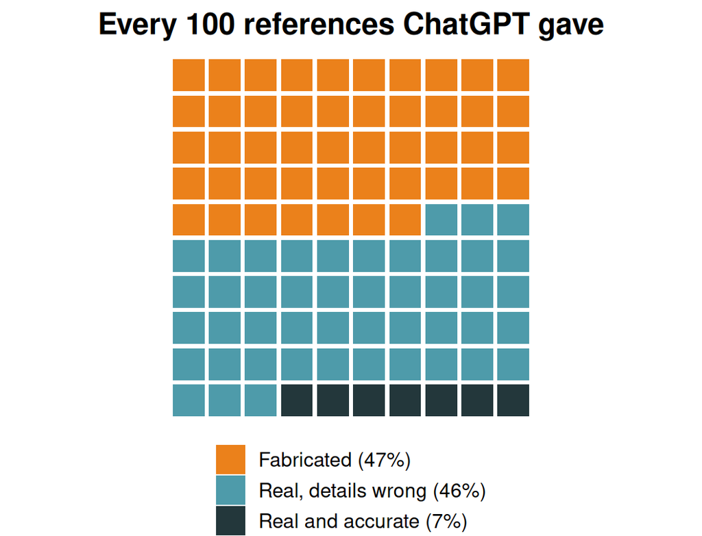

*Bhattacharyya et al. 2023, “High Rates of Fabricated and Inaccurate References in ChatGPT-Generated Medical Content”, Cureus. [doi:10.7759/cureus.39238](https://doi.org/10.7759/cureus.39238)*

## Asleep at the wheel?

When asked to write secure code, cybersecurity professionals using an AI assistant often wrote less secure code than their counterparts without it:

- They were also more likely to believe it was secure
- People who relied on the AI less made fewer mistakes
- It’s easy to skim AI output and miss due diligence details

Confident output makes us check less, so outside review needs to be careful.

*Perry et al. 2023, “Do Users Write More Insecure Code with AI Assistants?” [arXiv:2211.03622](https://arxiv.org/abs/2211.03622)*

## What is adversarial review?

Basically, a second pass whose job is to find problems + assumptions, flaws, and gaps.

- The AI does the work, then an *independent* reviewer looks for what’s wrong
- The reviewer can be a different AI model, or a fresh AI session
- You’re still the “final backstop”, the person who decides which problems are real and what to fix
- Same idea as peer review: *“what’s wrong with this?”*

## Some background

**Red teaming**

From military simulations, you make two squads and try to get them to outsmart the other and expose weaknesses. One AI writes test cases designed to make another AI fail.

**Debate**

Two AIs argue opposite sides, try to convince each other, a dialectical approach; a human judges who is right.

**Critic models**

AIs trained with human feedback to critique code caught more bugs than paid human code reviewers on their own.

*Perez et al. 2022, “Red Teaming Language Models with Language Models”. [arXiv:2202.03286](https://arxiv.org/abs/2202.03286)*  
*Irving et al. 2018, “AI safety via debate”. [arXiv:1805.00899](https://arxiv.org/abs/1805.00899)*  
*McAleese et al. 2024, “LLM Critics Help Catch LLM Bugs”. [arXiv:2407.00215](https://arxiv.org/abs/2407.00215)*

## Can’t I just ask AI to check its own work?

- No. “Are you sure?” in the same chat means the model re-judges its own answer with its same context and struggles to identify a problem
- Sometimes it’ll guess and switch a right answer to a wrong one, misleading you further
- Without outside feedback and examination, models (like people) struggle to correct their own reasoning and spot their own errors

*Huang et al. 2023, “Large Language Models Cannot Self-Correct Reasoning Yet”. [arXiv:2310.01798](https://arxiv.org/abs/2310.01798)*  
*Kamoi et al. 2024, “When Can LLMs Actually Correct Their Own Mistakes? A Critical Survey of Self-Correction of LLMs”. [arXiv:2406.01297](https://arxiv.org/abs/2406.01297)*

## But why?

**Self-preference**

Models can readily recognise their own writing, and score it higher than other models’ work and human-generated output, even when the other outputs are better. Models are also biased toward longer, more verbose answers.

**Sycophancy**

So: use a fresh session or a different model as the impartial reviewer, and avoid priming and biasing it with your own ideas.

*Panickssery et al. 2024, “LLM Evaluators Recognize and Favor Their Own Generations”. [arXiv:2404.13076](https://arxiv.org/abs/2404.13076)*  
*Sharma et al. 2023, “Towards Understanding Sycophancy in Language Models”. [arXiv:2310.13548](https://arxiv.org/abs/2310.13548)*

## Self-critique on its own is faulty

GPT-4 was tested on various mathematical puzzles and planning tasks and scored:

- When it critiqued its own answers, performance collapsed, switched right moves to wrong and didn’t fix wrong.
- Often suffered from compounding and stacked errors.
- When an outside verifier (e.g. a constraint checker, a logical gate checker) checked them, performance improved

For you, a “verifier” can be:

- Running the code/markdown and comparing, check outputs
- Checking the output on a small subset where you know the answer (e.g. a control or benchmark, reproduce someone else’s work)

*Stechly et al. 2024, “On the Self-Verification Limitations of Large Language Models on Reasoning and Planning Tasks”. [arXiv:2402.08115](https://arxiv.org/abs/2402.08115)*

## In conclusion

| Approach | Verdict |
| --- | --- |
| Checking against something real (run it, test it, known answer) | Works best |
| An independent reviewer (fresh session or different model) | Helps |
| Asking specific questions (“find the error in…”) | Helps |
| Several AIs debating | Mixed: often no better than simpler methods |
| Same AI, same chat, “are you sure?” | Weak |

YMMV with different approaches and models.

## Example: an AI-written analysis for illustrative purposes

Mouse liver, standard vs high-fat diet, 3 mice per group.

*Methods:* “Genes with padj < 0.05 and |log2FC| > 1 were called differentially expressed.”

```r
txi    <- tximport(files, type = "salmon", tx2gene = tx2gene)
counts <- round(txi$abundance)
dds    <- DESeqDataSetFromMatrix(counts, samples,
                                 design = ~ seq_run + diet)
dds    <- DESeq(dds)
res    <- lfcShrink(dds, coef = "diet_HFD_vs_standard",
                    type = "apeglm")
sig    <- subset(res, padj < 0.05)
```

| gene | log2FC | pvalue | padj |
| --- | --- | --- | --- |
| Cidea | 4.20 | 1.2e-14 | 2.3e-10 |
| Ddx3y | 6.30 | 8.1e-11 | 3.6e-07 |
| Kdm5d | 5.90 | 1.6e-08 | 3.8e-05 |
| Pparg | 1.20 | 3.0e-03 | 8.0e-04 |

*Results:* “The most strongly induced gene was *Cidea* (4.2-fold) … *Pparg* was also significantly increased (padj = 8.0e-04).”

Does it look fine to you?

*Constructed by BRC for illustrative purposes*

## Compare and contrast the outputs you might get

**Quick check**: *“Does this look OK?”*

> This looks like a solid, standard pipeline! Adjusting for sequencing run is a nice touch.

> One small thing: a log2FC of 4.2 is about 18-fold, not 4.2-fold.

> Want me to polish the wording?…

**Adversarial review**: *new chat, “find the problems”*

> 1. `txi$abundance` is TPM, not counts. DESeq2 needs counts.
> 2. The methods say |log2FC| > 1, but the code never applies it.
> 3. *Pparg*: an adjusted p-value can’t be smaller than its raw p-value.
> 4. *Ddx3y* and *Kdm5d* are Y-linked. Do the groups differ in sex?

*Constructed by BRC for teaching*

## Where does HI (human intelligence) come in?

AI flagged the chrY issue, you could check your lab notebook: all six mice were actually female.

- *Ddx3y* and *Kdm5d* are on the Y chromosome. Female mice shouldn’t express them at all. Was a sample mislabelled or contaminated?
- The AI can only point it out, it doesn’t have the full context of what you did and how and why.

Ask yourself what information the AI has access to and no access to:

- What do you know that isn’t on the page?
- Who checks the reviewer?

*Chromosome locations: NCBI Gene [Ddx3y (26900)](https://www.ncbi.nlm.nih.gov/gene/26900), [Kdm5d (20592)](https://www.ncbi.nlm.nih.gov/gene/20592), Mus musculus.*

## Adversarial review workflow

1. List what needs checking: each claim, number and step
2. Check each item in a fresh chat or a different model, without your biases and preconceptions
3. Ask specific questions (“find the error in…”) rather than “review this”
4. Ground it: run it, test it, compare to a known answer
5. You make the final call

*Dhuliawala et al. 2023, “Chain-of-Verification Reduces Hallucination in Large Language Models”. [arXiv:2309.11495](https://arxiv.org/abs/2309.11495)*  
*Liu & Shah 2023, “ReviewerGPT? An Exploratory Study on Using Large Language Models for Paper Reviewing”. [arXiv:2306.00622](https://arxiv.org/abs/2306.00622)*

## Want to try adversarial review?

Check out:

- https://github.com/k-dense-ai/scientific-agent-skills, or
- `/code-review` in Claude Code
- `/verify`

For more complete lists of skills, check out Tom and Doug’s slides, or try making your own if you’d like!

## Get your analysis checked at the BRC

biocritic is the BRC’s (currently in progress) AI reviewer for R and Python analyses, run entirely at Rockefeller on local models.

```
flowchart LR
  subgraph HPC ["All on the Rockefeller HPC"]
    direction LR
    A["Your code"] --> B["Automatic checks<br/>(no AI)"]
    B --> C["Three AI<br/>reviewers"]
    C --> D["Check against<br/>package docs"]
    D --> E["Ranked report"]
  end
  style HPC fill:none,stroke:#23373B,stroke-dasharray:5 5
```

Can catch

- off-by-one errors
- multiple testing errors
- data leakage
- and others!

84% of planted errors caught in test code

Want your code checked? brc@rockefeller.edu